# MA22004

10/12/2020

## Announcements

### Reminders

- It is week 10! This is our **last seminar before** the Class Test 3.
- You should have read §8 Quality Control on **Perusall**.
- Please look over the feedback from Class Test 2.

### Upcoming

- Lab 7 due **Thursday 10 Dec** at **17:00** (late accepted until Sunday w/o penalty).
- Worksheet #10 Review is already posted to Blackboard.
- Class Test 3 is **Wednesday 16 Dec** from **14:00–17:00**.

## What will Class Test 3 cover?

Class Test 3 will be longer than the first two tests and will be cumulative in nature, but will focus on the following topics.

- Categorical data (\(\chi^2\) tests for goodness of fit and independence)
- Linear regression (linear models, least squares estimates, inference for variances and least squares parameters, correlation)
- ANOVA (single factor tests and confidence intervals)

Revise inferences (hypothesis tests and confidence intervals) for single samples and two samples.

Monday’s workshop will include a review of important topics.

## Quality Control (QC)

- Identify the sources of random variations in output processes that might have *assignable causes*.
- **Control charts** help us to recognize when industrial processes are no longer controlled.
- Control charts use time series data to calculate the running value of a quality statistic.
- If the quality statistic exceed upper/lower control limits, process is deemed to be out of control (quality negatively impacted).

Workflow:

time series \(\longrightarrow\) control chart \(\longrightarrow\) identify assignable causes

## Beer Data: IPA

A brewer produces 3 batches of IPA per day and measures the pH value of each batch, which influences saccharification.

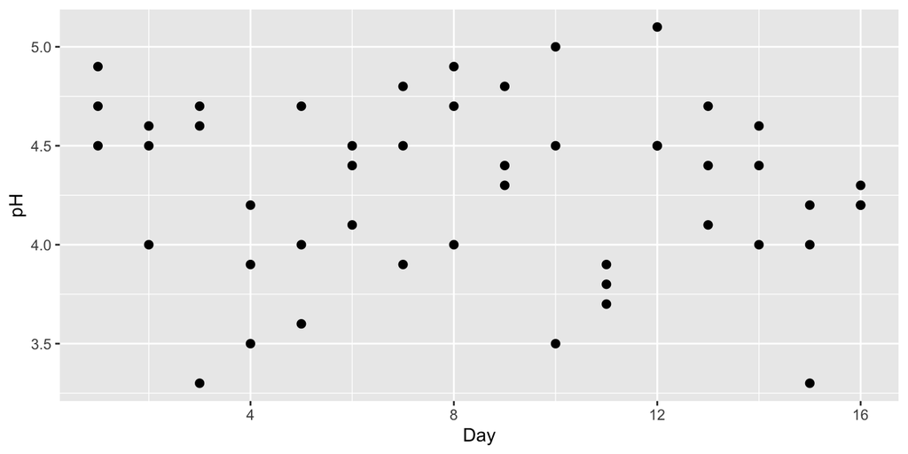

```r
ggplot(ipa, aes(x = Day, y = pH)) + geom_point(size = 2)
```

## \(3\sigma\) Control Chart

We consider the typical \(3\sigma\) control chart for the mean pH \(\overline{X}\).

Assume generating process \(X\) is normally distributed with unknown \(\mu\) and \(\sigma\).

Our control region is specified to by three standard deviations: the process remains in control if it stays three deviations within a baseline value.

Why consider three standard deviations from the mean?

## Checking for normality: `qqplot`

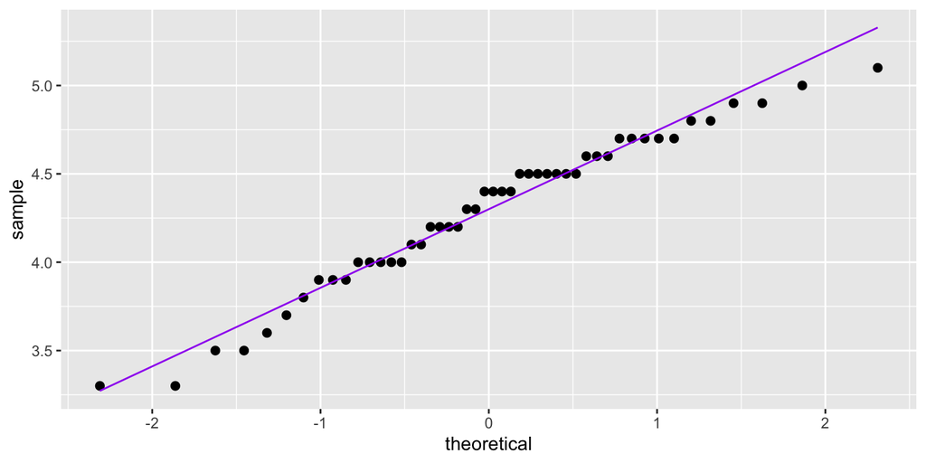

```r
ggplot(ipa, aes(sample = pH)) + stat_qq(size = 2) + stat_qq_line(color = "purple")
```

## Checking for normality: `shapiro.test`

Shapiro–Wilk tests the null hypothesis that a given sample came from a normally distributed population. Thus if \(P\)-value small, reject null and do no proceed.

```r
shapiro.test(ipa$pH)
```

```
    Shapiro-Wilk normality test

data:  ipa$pH
W = 0.96781, p-value = 0.2079
```

Failing to reject null does *not* tell us the population is normally distributed…

## Checking for normality ?

If the sample size is *large*, which should we use (`qqplot` vs `shapiro.test`)?

## Constructing a control chart

| Day | pH Observations | \(\overline{x}\) | \(s\) | Range |
| --- | --- | --- | --- | --- |
| 1 | 4.7, 4.5, 4.9 | 4.700 | 0.2000 | 0.4 |
| 2 | 4.0, 4.6, 4.5 | 4.367 | 0.3215 | 0.6 |
| 3 | 4.7, 3.3, 4.6 | 4.200 | 0.7810 | 1.4 |
| 4 | 3.9, 3.5, 4.2 | 3.867 | 0.3512 | 0.7 |
| 5 | 4.0, 4.7, 3.6 | 4.100 | 0.5568 | 1.1 |
| 6 | 4.4, 4.5, 4.1 | 4.333 | 0.2082 | 0.4 |

\(\widehat{\mu}\)

\(\widehat{\sigma}\)

## Estimating \(\sigma\)

Recall that the sample standard deviation is a biased estimator for the standard deviation.

For \(X_1, \dots, X_n \sim \mathsf{N}(\mu,\sigma^2)\), \[\mathop{\mathrm{\mathbf{E}}}(S) = a_n \cdot \sigma\] where the *bias correction* can be computed exactly: \[a_n = \sqrt{\frac{2}{n-1}}\frac{\Gamma(\tfrac{n}{2})}{\Gamma(\tfrac{n-1}{2})} \,.\]

| \(n\) | 3 | 4 | 5 | 6 | 7 | 8 |
| --- | --- | --- | --- | --- | --- | --- |
| \(a_n\) | 0.886 | 0.921 | 0.94 | 0.952 | 0.959 | 0.965 |

## Unbiased estimator \(\sigma\)

Let \(\overline{S} = \frac{1}{k} \sum_{i=1}^k S_i\), where \(S_i\) are the sample sd for \(k\) days.

## Control limits based on sample sds

\[\mathsf{LCL} = \widehat{\mu} - 3 \frac{\overline{s}}{a_n \sqrt{n}}\] \[\mathsf{UCL} = \widehat{\mu} + 3 \frac{\overline{s}}{a_n \sqrt{n}}\] where

\(\widehat{\mu} = \frac{1}{k} \sum_{i=1}^k \overline{x}_i\)

\(\overline{s} = \frac{1}{k} \sum_{i=1}^k s_i\)

## Control Chart

- Assume process is in-control over the 16 days and compute the limits.
- Violation would require that we seek to identify an assignable cause.

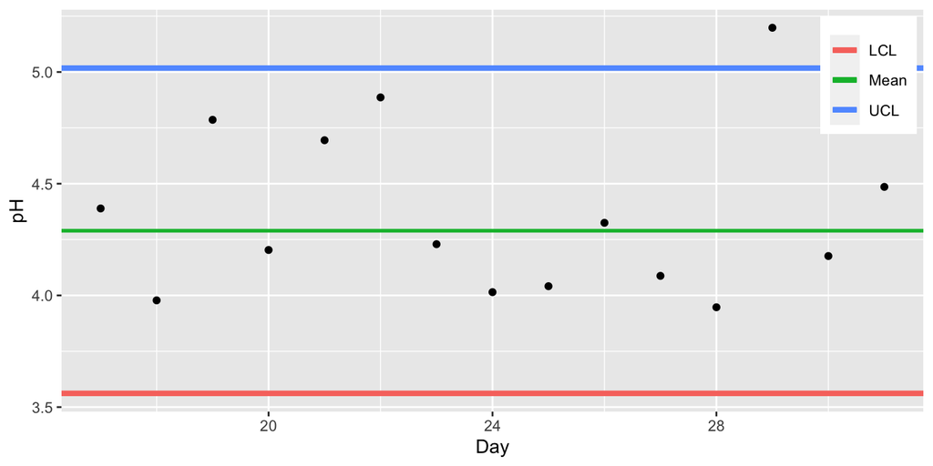

## Summary

Today we discussed control charts for Quality Control.

We learned about bias correction for estimating the population standard deviation.